# Machine Learning Assesment

Sergey Chigrinov

December 21, 2015

In this work we will try to predict activity quality from activity monitors. For the analysis we’ll use the Weight Lifting Exercise Dataset, from the following paper: Velloso, E.; Bulling, A.; Gellersen, H.; Ugulino, W.; Fuks, H. Qualitative Activity Recognition of Weight Lifting Exercises. Proceedings of 4th International Conference in Cooperation with SIGCHI (Augmented Human ’13) . Stuttgart, Germany: ACM SIGCHI, 2013.

```r
#knitr::opts_chunk$set(cache=TRUE)
knitr::opts_chunk$set(warning=FALSE, message=FALSE, fig.path='Figs/')
set.seed(1)
```

```r
setwd("~/Sergey/Coursera/DataScience/Mashine learning/PeerAssessment")
library(tree)
library(caret)
library(randomForest)
```

```r
   trainData <- read.csv("pml-training.csv",na.strings=c("", "NA", "NULL"))
   validationData <- read.csv("pml-testing.csv",na.strings=c("", "NA", "NULL"))
```

## Preprocessing

```r
dim(trainData)
```

```
## [1] 19622   160
```

There are 19622 obs. of 160 variables. A lot of values of some variables are missing, and there are some unnecessary columns, so we need to clean our data.

```r
goodvar <- sapply(trainData, function(x) {sum(is.na(x))})==0
trainData <- trainData[,goodvar]
trainData <- trainData[, -1:-6]
dim(trainData)
```

```
## [1] 19622    54
```

The variable we need to predict is train$classe.

```r
levels(trainData$classe)
```

```
## [1] "A" "B" "C" "D" "E"
```

The “classe” variable has 5 levels.

To perform cross-validation testing we need to split the initial data set into training and testing sets.

```r
inTrain <- createDataPartition(trainData$classe,p=0.75, list=FALSE)
training <- trainData[inTrain,]
testing <- trainData[-inTrain,]
```

## Model fitting

Since the objective is classification, we’ll try to use Classification Tree and Random Forest algorythms. For the classification we’ll use “tree” package - seems like it produces better results that “caret” package, and works faster. It could be because of some defaults or due to implementation.

Classification tree:

```r
fitTree <- tree(classe ~ ., data=training)
testPredTree=predict(fitTree,training, type = "class")
trainConfusion <- confusionMatrix(testPredTree, training$classe)
testPredTree=predict(fitTree,testing, type = "class")
testConfusion <- confusionMatrix(testPredTree, testing$classe)
trainConfusion$overall
```

```
##       Accuracy          Kappa  AccuracyLower  AccuracyUpper   AccuracyNull
##   7.153825e-01   6.413461e-01   7.080165e-01   7.226633e-01   2.843457e-01
## AccuracyPValue  McnemarPValue
##   0.000000e+00  9.583005e-269
```

```r
accTree <- testConfusion$overall[1]
testConfusion$overall
```

```
##       Accuracy          Kappa  AccuracyLower  AccuracyUpper   AccuracyNull
##   7.255302e-01   6.540704e-01   7.128069e-01   7.379845e-01   2.844617e-01
## AccuracyPValue  McnemarPValue
##   0.000000e+00   1.319750e-73
```

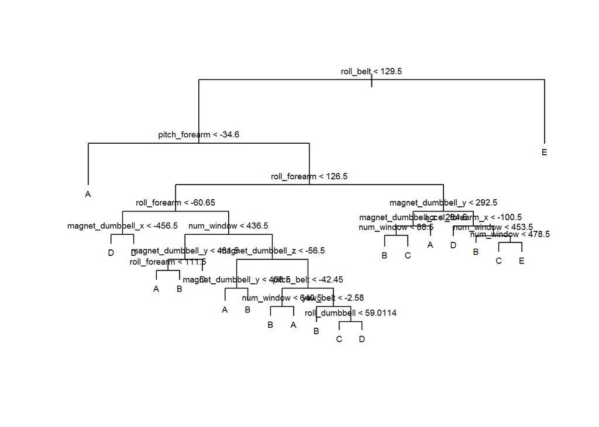

```r
plot(fitTree)
text(fitTree,pretty=0, cex =.6)
```

```r
testConfusion$table
```

```
##           Reference
## Prediction    A    B    C    D    E
##          A 1198   97    3   14   22
##          B   61  580   45   83   99
##          C   13   33  712  177   48
##          D  103  200   94  516  180
##          E   20   39    1   14  552
```

We have `27.45`% of incorrect results for test set for the Classification Tree. Our out of sample error is not satisfactory.

We’ll try to improve the result by using Random Forest algorythm. Let’s grow 100 trees for our random forest. Randon forest:

```r
#by default ntree=500, but for our task it should be enough to use ntree=100
fitForest=randomForest(classe~.,data=training,ntree=100)
```

Variable Importance (first 20 var.)

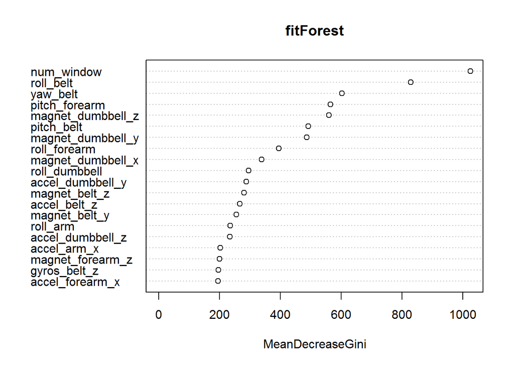

```r
varImpPlot(fitForest, n.var=20)
```

```r
testPredForest=predict(fitForest,training, type = "class")
trainConfusion <- confusionMatrix(testPredForest, training$classe)
testPredForest=predict(fitForest,testing, type = "class")
testConfusion <- confusionMatrix(testPredForest, testing$classe)
trainConfusion$overall
```

```
##       Accuracy          Kappa  AccuracyLower  AccuracyUpper   AccuracyNull
##      1.0000000      1.0000000      0.9997494      1.0000000      0.2843457
## AccuracyPValue  McnemarPValue
##      0.0000000            NaN
```

```r
accForest <- testConfusion$overall[1]
testConfusion$overall
```

```
##       Accuracy          Kappa  AccuracyLower  AccuracyUpper   AccuracyNull
##      0.9985726      0.9981944      0.9970612      0.9994259      0.2844617
## AccuracyPValue  McnemarPValue
##      0.0000000            NaN
```

```r
testConfusion$table
```

```
##           Reference
## Prediction    A    B    C    D    E
##          A 1395    2    0    0    0
##          B    0  947    1    0    0
##          C    0    0  854    4    0
##          D    0    0    0  800    0
##          E    0    0    0    0  901
```

The accuracy of the algorythm on the test set is 99.8572594% - much better than the result of the classification tree.

## Final model and result

```r
finalFitForest=randomForest(classe~.,data=trainData,ntree=100)
answers <- predict(finalFitForest,validationData, type = "class")
answers
```

```
##  1  2  3  4  5  6  7  8  9 10 11 12 13 14 15 16 17 18 19 20
##  B  A  B  A  A  E  D  B  A  A  B  C  B  A  E  E  A  B  B  B
## Levels: A B C D E
```

Write the answers to files:

```r
setwd("~/Sergey/Coursera/DataScience/Mashine learning/PeerAssessment/Submission")
pml_write_files = function(x){
  n = length(x)
  for(i in 1:n){
    filename = paste0("problem_id_",i,".txt")
    write.table(x[i],file=filename,quote=FALSE,row.names=FALSE,col.names=FALSE)
  }
}

pml_write_files(answers)
```